# Assignment: Practical Machine Learning

rahlumin_AT_gmail

07/27/2014

The problem presented in this assignment posed many challanges and and helped me understand the issues with MAchine Learning.

**Type of Problem:** The problem is clearly a Classification Problem as the class variable is a factor variable.

**Selection of algorithm:** As this is a classification problem, Random Forest, Rpart , glm and naive bayesian were tried. Random Foret and glm worked best.

**Data Splitting:** Given the large number of observations (~20,000) the Training data was further split in Training and Validation/Test data in the ratio of 60:40 . While a k-folds validatin was dome on the training subdivision, the testing subdivision was only used once to assess out of sample errors.

**Preprocessing Used:** First off, there were many null values and many factor variables. IT was ensured that all blanks were converted to NAs at the time of reading the csv.

```r
dt<-read.csv("pml-training.csv", na.strings = c("NA",""))
```

All the columns with na’s were later removed, and only numerical colums(other than the classification column) were retained.

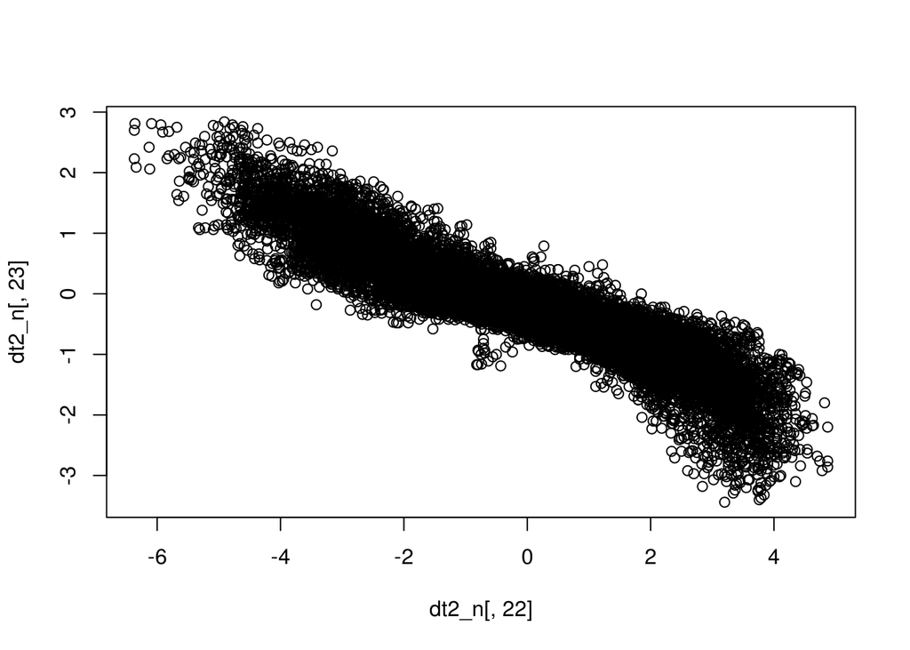

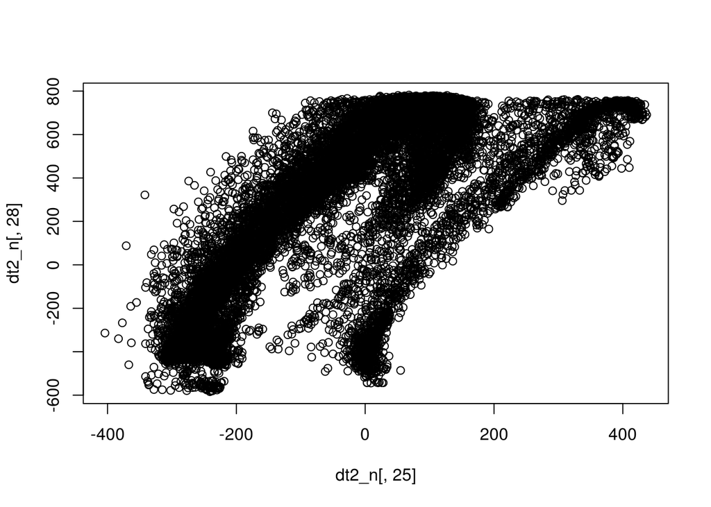

To pare down the number of columns, PCA was used as an argument to train function.

```r
applyMethod<-function(meth)
{
  print("======training, method is====")
  print(meth)
  #we shall restrict it to 15 folds and 5 repeats
  tc<-trainControl(method ="cv",number = 15,repeats = 5 )
  modFit<-train(classe ~ ., trControl = tc,
                method=meth, preProcess="pca", data = training   )
  #summary(modFit$finalModel)
  pred<-predict(modFit, testing)
  conf<-confusionMatrix(pred,testing$classe )
  print( conf$overall )
  print("xxxxxxxxxxend train xxxxxxxxxxx")
  return(modFit)
}
```

Running this with Random Forest Model provides following Result:

```
      Accuracy          Kappa  AccuracyLower  AccuracyUpper   AccuracyNull
     0.9795988      0.9741730      0.9738167      0.9843965      0.2852771
AccuracyPValue  McnemarPValue
     0.0000000            NaN
```

Testing against the validation subset set aside provides follwoing result

```
          Reference
Prediction    A    B    C    D    E
         A 2216   22    3    0    0
         B    5 1482   28    1    0
         C    0   23 1324   33    0
         D    0    0    5 1261    4
         E    0    0    2    6 1434
```

```
Overall Statistics

               Accuracy : 0.9832
                 95% CI : (0.9801, 0.9859)
    No Information Rate : 0.283
    P-Value [Acc > NIR] : < 2.2e-16

                  Kappa : 0.9787
```

Give an accuracy of 0.98 with validation set I expected an accuracy aroun 75-80 % on new sample. Howwever, when tested agains the test csv provided (submitted values) the accuracy was found to be 65* for the 20 observations provided.

```
             =======X=====
```